# Trajectories and the Phase Plane

# Recap: The Phase Plane

The phase plane consists of

- Axes labeled with the state variables
- Nullclines for each variable (preferrably in different colors)
- Equilibria labeled by their coordinates.

We will add more to this, but when I ask you to “make a phase plane,” these are the essential three ingredients.

### Example 1

Make a phase plane for the following system of differential equations. (Side note: I just made this example up out of thin air.)
$$\begin{align*}
\frac{dx}{dt} &= y x - 2y^2\\
\frac{dy}{dt} &= 2x + 1
\end{align*}$$

First, let’s find the nullclines. For $x$, we’ll have $y(x-2y)=0$, giving two figures: the horizontal line $y=0$ and the slanted line $y=\frac{1}{2}x$.

For the $y$ nullclines, we only get a vertical line $2x+1= 0$, or $x=-\frac{1}{2}$. Here’s what it looks like. Notice we only have two equilibria.

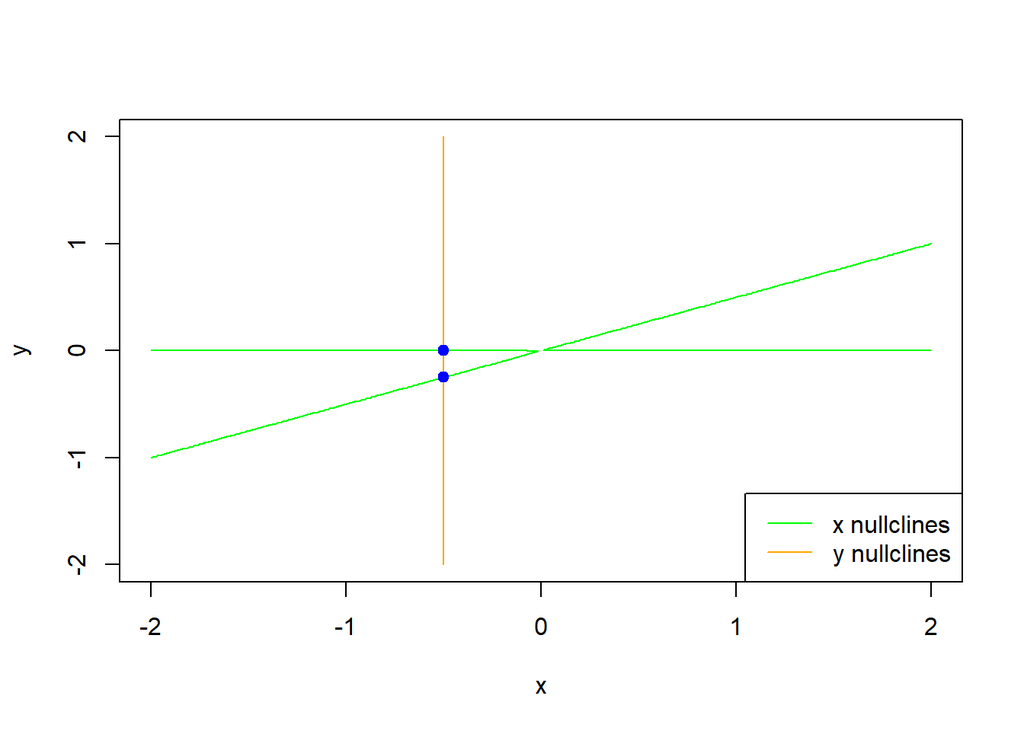

What are those equilibria? The $x$ coordinates are easy: both are $-0.5$. For the top equilibrium, you get $y=0$, so that equilibrium is $(x^*,y^*)= (-0.5, 0)$. For the other, it lies on the line $y=0.5 x$. Therefore, the $y$-value is $0.5(-0.5) = -0.25$. We get the equilibria
$$(x^*,y^*) = (-0.5, 0) \quad \text{ and } \quad (x^*,y^*) = (-0.5, -0.25).$$

# Trajectories

Remember, the whole point of a system of differential equations (or any differential equation whatsoever) is to know what the *solutions* $x(t)$ and $y(t)$ do in time. The way we show this on the phase plane is through a *trajectory*.

**Definition.** A trajectory is a *path* in the phase plane that shows the values of $x(t)$ and $y(t)$ in time.

Let’s understand first what a trajectory looks like and what it tells us.

### Example 2: Looking at a trajectory

Suppose we have the following graph, which represents a trajectory in phase space.

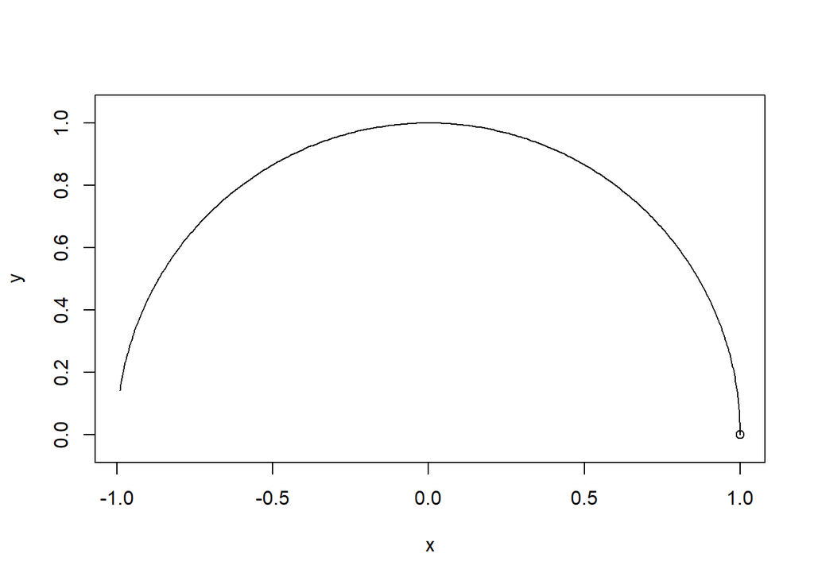

We assume that the trajectory starts at the little circle on the bottom right. Here’s what we can draw from this trajectory: $x(t)$ starts at 1, then decreases over time, until it ends at $x\approx -1$ at some later time.

On the other hand, $y$ starts at $0$, increases to a max of $y=1$, then decreases to a value near $0$ at some later time.

You might end up drawing graphs looking like this:

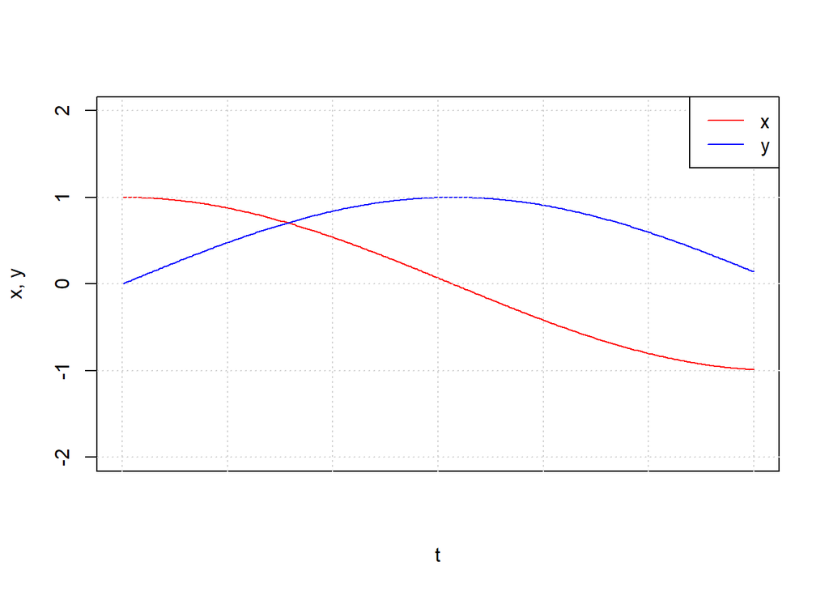

What we *cannot* tell from the trajectory is the *time length*. A trajectory only shows us the $x$ and $y$ values that are hit, not when they hit them!

We will talk about how we get trajectories soon.

### Example 3

Draw the solutions $x(t)$ and $y(t)$ from the given trajectory below.

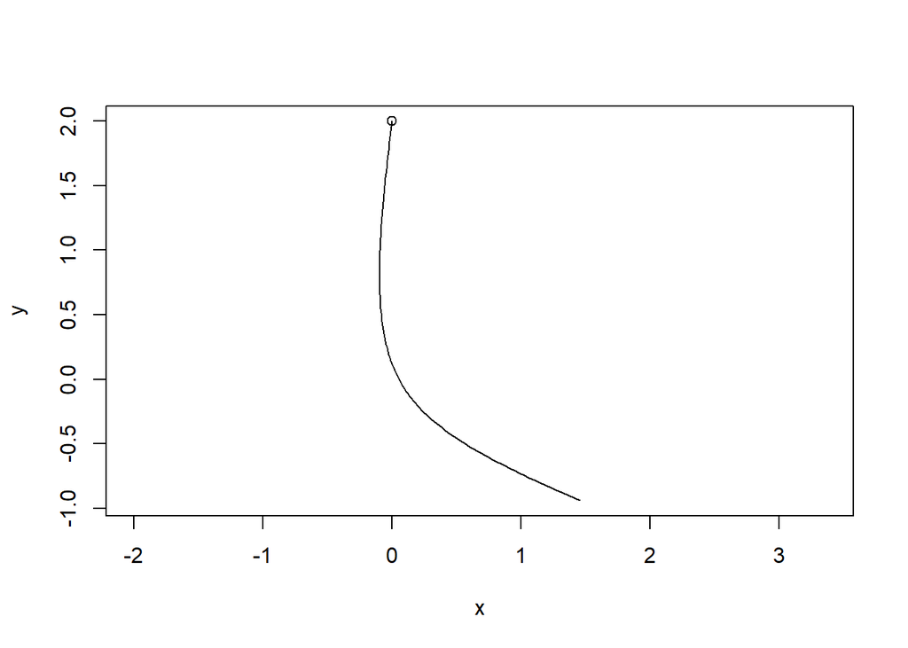

This is a possible trajectory! It looks strange. We start at $x=0$, $y=2$. Focus on $x$: as time goes on, $x$ stays almost the same, but decreasing slightly until a massive upspike occurs, where $x$ starts to increase dramatically.

On the other hand, $y$ does nothing but decrease! So the two functions $x(t)$ and $y(t)$ you might draw look like this.

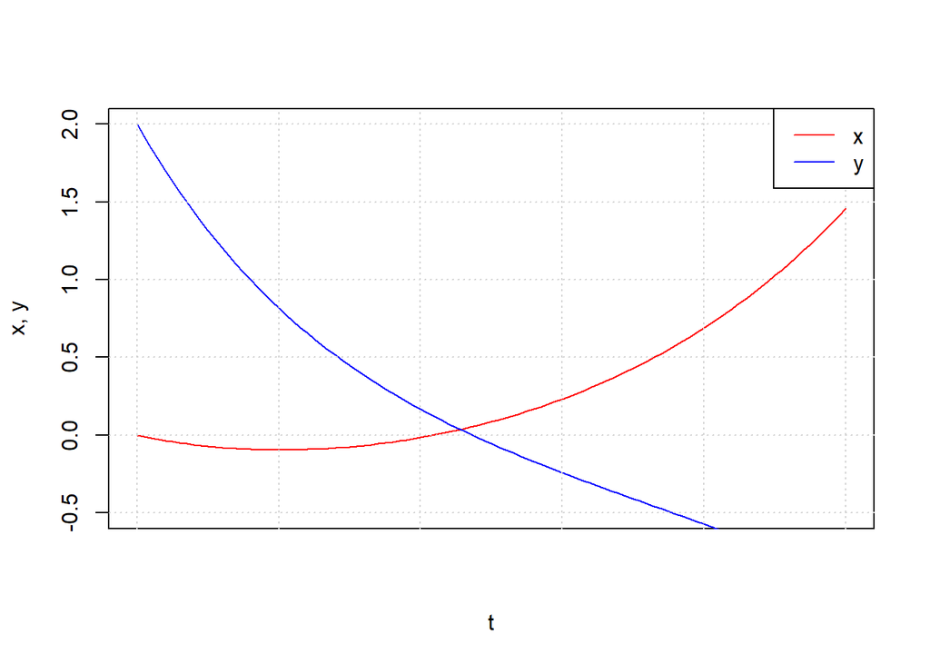

### Example 4

Draw the functions $x(t)$ and $y(t)$ corresponding to this trajectory.

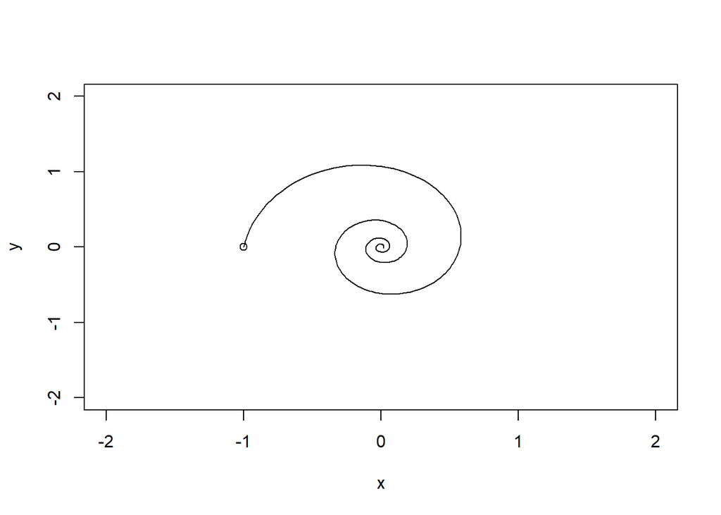

Here is what you should (roughly) get:

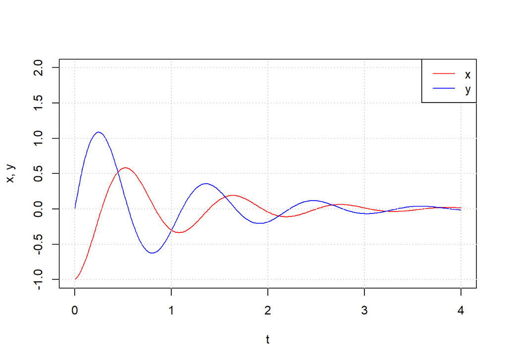

# Direction Fields, or how trajectories are made

We get trajectories from the system of differential equations. We can either ask a computer to make a very accurate trajectory, or we can sketch them by hand. Computers make them with a two-dimensional version of Euler’s Method. We do have a way of making sense of them by hand, at least approximately. We use what’s called a *direction field*.

Here’s what you do: pick a point $(x,y)$ in the phase plane. Then plug these into the system to get $(dx/dt, dy/dt)$ values (like you were about to do Euler’s method). This gives you two different numbers, and then use these to make an arrow.

### Example 5

Let’s return to the system we had before:
$$\begin{align*}
\frac{dx}{dt} &= y x - 2y^2\\
\frac{dy}{dt} &= 2x + 1
\end{align*}$$
Let’s pick the point $(x,y)=(1,1)$. Doing so gives you $\frac{dx}{dt} = -1$ and $\frac{dy}{dt} = 3$, producing the pair $(-1,3)$. This is an arrow pointing to the left by 1 and up 3. [Side bar: if you know vectors, this is a vector.]

If we do $(x,y)=(1,0)$, we get $\frac{dx}{dt} = 0$ and $\frac{dy}{dt} = 3$. We would draw this as a vector pointing upwards.

Below is a plot showing these arrows, as well as vectors at the points $(x,y)=(0,1)$ and $(0,0)$.

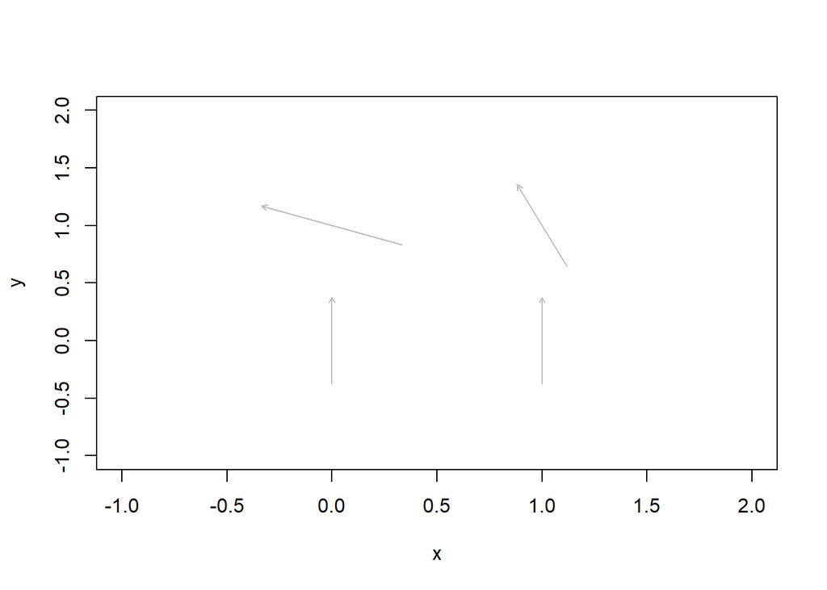

Of course, we can make as many arrows as we want: this is called the *direction field*.

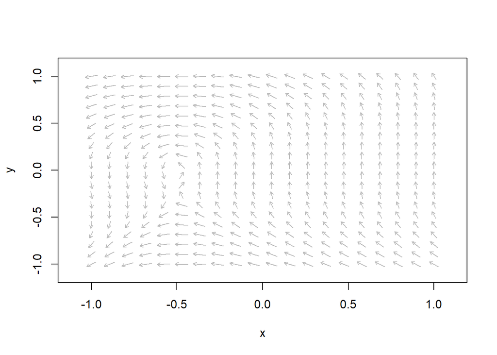

This picture is just a zoom-out of the previous one; the arrows look more clustered only because we are adding a bunch more test points.

Once you have a direction field, a trajectory begins at an intial condition, and then “follows the arrows.” So, in the above example, here is a plot of a trajectory beginning at $(x(0),y(0)) = (0,-0.5)$:

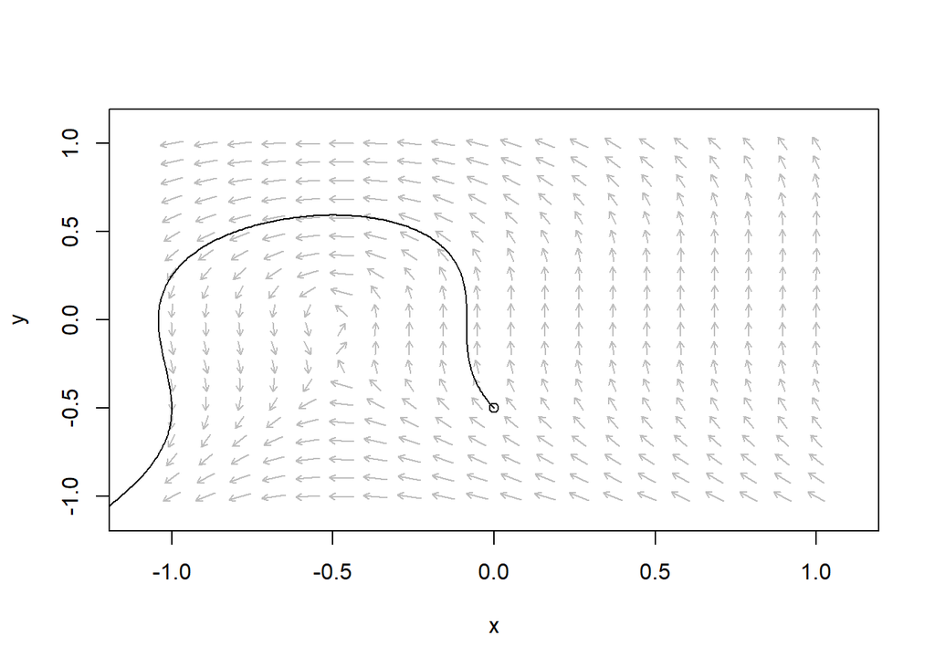

# Summary of Phase Planes

Here’s the summary for all of the components of a phase plane. Given any system of two differential equations, we perform the following:

1. Make a set of axes with the state variables.
2. Make nullclines and identify equilibria.
3. Make a bunch of direction vectors using the differential equations.
4. Make a few trajectories that follow the direction vectors.
5. Turn trajectories into information about the state variables $x$ and $y$.

# Questions I might ask you

Here are some possible questions I might ask you:

## Given a system of DE’s, draw a few direction vectors in the phase plane.

1. Draw direction vectors for the system below at the locations $(0,0)$, $(1,1)$, $(0,1)$, and $(1,0)$.
   $$\begin{align*}
   \frac{dx}{dt} &= 4x + 3y \\
   \frac{dy}{dt} &= -2x - y
   \end{align*}$$

## Draw the nullclines and find equilibria.

2. Do it for these systems:
1. $$\begin{align*}
   \frac{dx}{dt} &= 4x + 3y\\
   \frac{dy}{dt} &= -2x - y
   \end{align*}$$
2. $$\begin{align*}
   \frac{ds}{dt} &= 2s^2 - s r \\
   \frac{dr}{dt} &= rs - 1
   \end{align*}$$

## Sketch trajectories from a given direction field.

3. Sketch trajectories on the direction field below beginning at $(x(0),y(0))=(1,1)$ and $(-1,0)$.

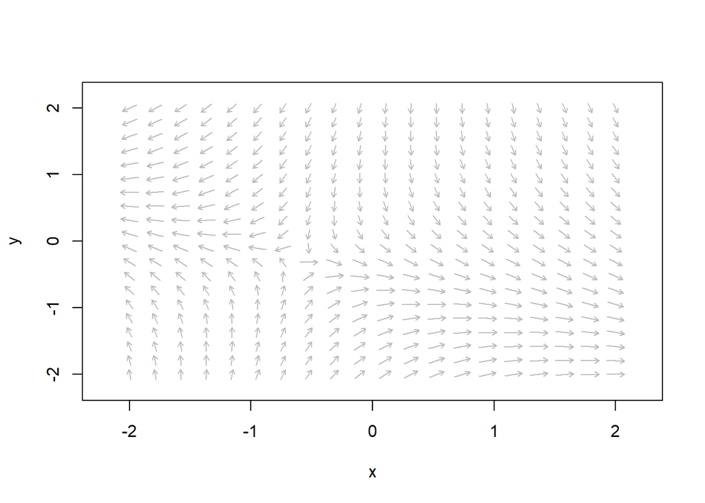

## Sketch solutions $x(t)$ and $y(t)$ from a trajectory.

4. Sketch solutions $x(t)$ and $y(t)$ given the following three trajectories.

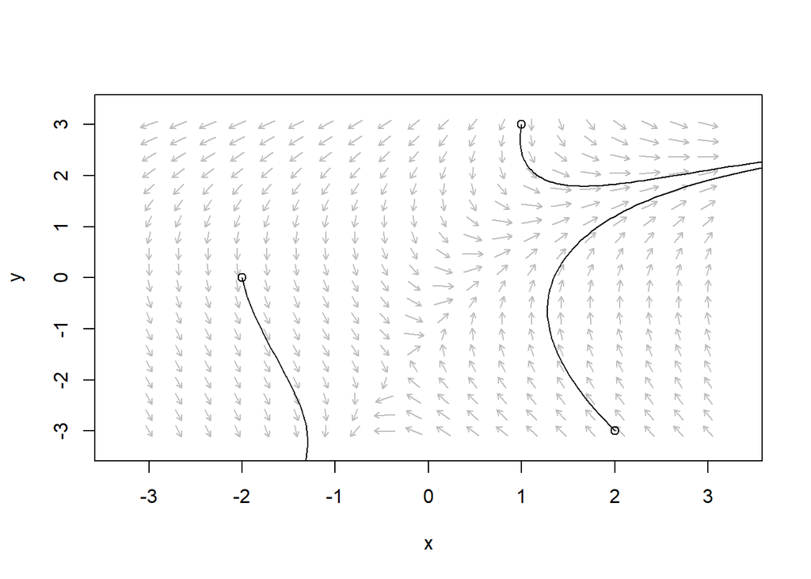